# Case Study 4 : Data Dissection

## Question 1. If I am leaving before noon, which two airlines do you recommend at each airport (JFK, LGA, EWR) that will have the lowest delay time at the 75th percentile?

Strip Off Dep_Delay Outliers using https://rpubs.com/Mentors_Ubiqum/removing_outliers

```r
outliers <- boxplot(flts$dep_delay, plot=FALSE)$out #assign the outlier values into a vector
print(outliers) # Check the results
```

```
##     [1]   47   39  101   71  853   43   59  144  134   96   41   55   71   37
##    [15]   77   40   57   70   39   56   59  115   38   50  105   38  122   88
##    [29]   64  119   54   84   88   64   42   52   82   36   71   91   88   62
##    [43]   56   70   88   54   37  103   74  290   70  260   61   63  131   46
##    [57]  105  129  155   59  157   50  216   73  121   46   36   42   38  109
##    [71]   56   51   52   72   50  255  109   41   49  285   47  141   62  192
##    [85]   83  116   37  379   43  156   80   42   79  107   36  155   45   39
##    [99]   46   43   49  179   75   63   56  104   51  103   64   46  100   40
##   [113]   65  120   36  103   36   39  224   90  268   71  101   65   42   43
##   [127]  334   67   46   75  139   52   69   37   99   42  128   70   59   46
##   [141]  337   76   62  101   43   98  104   79   91  133   67   85   55  181
##   [155]   53   75  128   37   75   66  102   85   97   67   40   75   48   67
##   [169]   67   48   50  120  107   85   47   52  168   36  103  109   39   37
##   [183]   40   80   53  180   97   59  164   39   75   40   82   74  158   71
##   [197]  379  140  104  105  175   65   65  119   69  108  125  102   62  185
```

[output cut: 3072 more lines]

```r
flts[which(flts$dep_delay %in% outliers),] # First you need find in which rows the outliers are
```

```
## # A tibble: 43,216 x 19
##     year month   day dep_time sched_dep_time dep_delay arr_time sched_arr_time
##    <int> <int> <int>    <int>          <int>     <dbl>    <int>          <int>
##  1  2013     1     1      732            645        47     1011            941
##  2  2013     1     1      749            710        39      939            850
##  3  2013     1     1      811            630       101     1047            830
##  4  2013     1     1      826            715        71     1136           1045
##  5  2013     1     1      848           1835       853     1001           1950
##  6  2013     1     1      903            820        43     1045            955
##  7  2013     1     1      909            810        59     1331           1315
##  8  2013     1     1      957            733       144     1056            853
##  9  2013     1     1     1114            900       134     1447           1222
## 10  2013     1     1     1120            944        96     1331           1213
## # ... with 43,206 more rows, and 11 more variables: arr_delay <dbl>,
## #   carrier <chr>, flight <int>, tailnum <chr>, origin <chr>, dest <chr>,
## #   air_time <dbl>, distance <dbl>, hour <dbl>, minute <dbl>, time_hour <dttm>
```

```r
fltsout <- flts[-which(flts$dep_delay %in% outliers),]  #remove the rows containing the outliers
str(fltsout)  #look at the data without outliers
```

```
## tibble [293,560 x 19] (S3: tbl_df/tbl/data.frame)
##  $ year          : int [1:293560] 2013 2013 2013 2013 2013 2013 2013 2013 2013 2013 ...
##  $ month         : int [1:293560] 1 1 1 1 1 1 1 1 1 1 ...
##  $ day           : int [1:293560] 1 1 1 1 1 1 1 1 1 1 ...
##  $ dep_time      : int [1:293560] 517 533 542 544 554 554 555 557 557 558 ...
##  $ sched_dep_time: int [1:293560] 515 529 540 545 600 558 600 600 600 600 ...
##  $ dep_delay     : num [1:293560] 2 4 2 -1 -6 -4 -5 -3 -3 -2 ...
##  $ arr_time      : int [1:293560] 830 850 923 1004 812 740 913 709 838 753 ...
##  $ sched_arr_time: int [1:293560] 819 830 850 1022 837 728 854 723 846 745 ...
##  $ arr_delay     : num [1:293560] 11 20 33 -18 -25 12 19 -14 -8 8 ...
##  $ carrier       : chr [1:293560] "UA" "UA" "AA" "B6" ...
##  $ flight        : int [1:293560] 1545 1714 1141 725 461 1696 507 5708 79 301 ...
##  $ tailnum       : chr [1:293560] "N14228" "N24211" "N619AA" "N804JB" ...
##  $ origin        : chr [1:293560] "EWR" "LGA" "JFK" "JFK" ...
##  $ dest          : chr [1:293560] "IAH" "IAH" "MIA" "BQN" ...
##  $ air_time      : num [1:293560] 227 227 160 183 116 150 158 53 140 138 ...
##  $ distance      : num [1:293560] 1400 1416 1089 1576 762 ...
##  $ hour          : num [1:293560] 5 5 5 5 6 5 6 6 6 6 ...
##  $ minute        : num [1:293560] 15 29 40 45 0 58 0 0 0 0 ...
##  $ time_hour     : POSIXct[1:293560], format: "2013-01-01 05:00:00" "2013-01-01 05:00:00" ...
```

```r
summary(fltsout)  #look at the data without outliers
```

```
##       year          month             day          dep_time    sched_dep_time
##  Min.   :2013   Min.   : 1.000   Min.   : 1.0   Min.   :   1   Min.   : 106
##  1st Qu.:2013   1st Qu.: 4.000   1st Qu.: 8.0   1st Qu.: 850   1st Qu.: 855
##  Median :2013   Median : 7.000   Median :16.0   Median :1314   Median :1320
##  Mean   :2013   Mean   : 6.577   Mean   :15.7   Mean   :1298   Mean   :1308
##  3rd Qu.:2013   3rd Qu.:10.000   3rd Qu.:23.0   3rd Qu.:1705   3rd Qu.:1705
##  Max.   :2013   Max.   :12.000   Max.   :31.0   Max.   :2400   Max.   :2359
##                                                 NA's   :8255
##    dep_delay          arr_time    sched_arr_time   arr_delay
##  Min.   :-27.000   Min.   :   1   Min.   :   1   Min.   :-86.000
##  1st Qu.: -5.000   1st Qu.:1058   1st Qu.:1110   1st Qu.:-18.000
##  Median : -3.000   Median :1505   Median :1517   Median : -8.000
##  Mean   :  0.444   Mean   :1489   Mean   :1507   Mean   : -5.588
##  3rd Qu.:  2.000   3rd Qu.:1914   3rd Qu.:1920   3rd Qu.:  5.000
##  Max.   : 35.000   Max.   :2400   Max.   :2359   Max.   :194.000
##  NA's   :8255      NA's   :8509                  NA's   :9071
##    carrier              flight       tailnum             origin
##  Length:293560      Min.   :   1   Length:293560      Length:293560
##  Class :character   1st Qu.: 544   Class :character   Class :character
##  Mode  :character   Median :1467   Mode  :character   Mode  :character
##                     Mean   :1928
##                     3rd Qu.:3386
##                     Max.   :6181
##
##      dest              air_time        distance         hour
##  Length:293560      Min.   : 20.0   Min.   :  17   Min.   : 1.00
##  Class :character   1st Qu.: 83.0   1st Qu.: 509   1st Qu.: 8.00
##  Mode  :character   Median :131.0   Median : 888   Median :13.00
##                     Mean   :152.3   Mean   :1051   Mean   :12.82
##                     3rd Qu.:194.0   3rd Qu.:1391   3rd Qu.:17.00
##                     Max.   :695.0   Max.   :4983   Max.   :23.00
##                     NA's   :9071
##      minute        time_hour
##  Min.   : 0.00   Min.   :2013-01-01 05:00:00
##  1st Qu.: 7.00   1st Qu.:2013-04-03 15:00:00
##  Median :29.00   Median :2013-07-06 06:00:00
##  Mean   :26.04   Mean   :2013-07-04 01:49:12
##  3rd Qu.:44.00   3rd Qu.:2013-10-03 09:00:00
##  Max.   :59.00   Max.   :2013-12-31 23:00:00
##
```

```r
fo3am <- filter(fltsout, hour < 12, origin %in% c("JFK","LGA","EWR")) #filter for rows that are before noon and depart from these three airports

fo3ambyarpt <- group_by(fo3am, origin, carrier)   #group by carrier and origin
grpd <- summarise(fo3ambyarpt, Q3depdelay = quantile(dep_delay, c(.75), na.rm = TRUE)) # Produce the 75thpercentile for each airport
str(grpd)
```

```
## tibble [33 x 3] (S3: grouped_df/tbl_df/tbl/data.frame)
##  $ origin    : chr [1:33] "EWR" "EWR" "EWR" "EWR" ...
##  $ carrier   : chr [1:33] "9E" "AA" "AS" "B6" ...
##  $ Q3depdelay: Named num [1:33] -3 -1 0 -2 -2 0 0 2 -2 -1 ...
##   ..- attr(*, "names")= chr [1:33] "75%" "75%" "75%" "75%" ...
##  - attr(*, "groups")= tibble [3 x 2] (S3: tbl_df/tbl/data.frame)
##   ..$ origin: chr [1:3] "EWR" "JFK" "LGA"
##   ..$ .rows : list<int> [1:3]
##   .. ..$ : int [1:11] 1 2 3 4 5 6 7 8 9 10 ...
##   .. ..$ : int [1:10] 12 13 14 15 16 17 18 19 20 21
##   .. ..$ : int [1:12] 22 23 24 25 26 27 28 29 30 31 ...
##   .. ..@ ptype: int(0)
##   ..- attr(*, ".drop")= logi TRUE
```

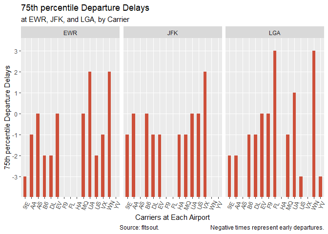

```r
grpd$carrier <- as.factor(grpd$carrier)
grpd$Q3depdelay <- as.factor(grpd$Q3depdelay)


# Draw Bar Chart plot
ggplot(grpd, aes(x = carrier, y = Q3depdelay)) +
#ggplot(grpd, aes(x = reorder(Q3depdelay,origin,carrier), y = Q3depdelay)) +
  geom_bar(stat="identity", width=.5, fill="tomato3") +
  facet_wrap(~ origin) +
  labs(title="75th percentile Departure Delays",
       subtitle="at EWR, JFK, and LGA, by Carrier",
       caption="Source: fltsout.                                   Negative times represent early departures.",
       y = "75th percentile Departure Delays",
       x = "Carriers at Each Airport") +
  theme(axis.text.x = element_text(angle=65, vjust=0.6))
```

### Interpretation:

Note that negative numbrs are early departures, so the most reliable will have the most negative 75th percentile.  
At EWR, the 2 most reliable carriers are 9E and a three-way tie for seci=ond place between B6, DL, and US.  
At JFK, the 2 most reliable carriers are a five way tie between: 9E, DL, EV, HA and MQ.  
At LGA, the 2 most reliable carriers are US and YV.

## Question 2. Which origin airport is best to minimize my chances of a late arrival (AT THE OTHER END) when I am using Delta Airlines?

Install and read in the appropriate libraries

```r
library(ggplot2)
library(dplyr)
library(tidyverse)
```

Read and inspect in the data

```r
flts <- nycflights13::flights
str(flts)
```

```
## tibble [336,776 x 19] (S3: tbl_df/tbl/data.frame)
##  $ year          : int [1:336776] 2013 2013 2013 2013 2013 2013 2013 2013 2013 2013 ...
##  $ month         : int [1:336776] 1 1 1 1 1 1 1 1 1 1 ...
##  $ day           : int [1:336776] 1 1 1 1 1 1 1 1 1 1 ...
##  $ dep_time      : int [1:336776] 517 533 542 544 554 554 555 557 557 558 ...
##  $ sched_dep_time: int [1:336776] 515 529 540 545 600 558 600 600 600 600 ...
##  $ dep_delay     : num [1:336776] 2 4 2 -1 -6 -4 -5 -3 -3 -2 ...
##  $ arr_time      : int [1:336776] 830 850 923 1004 812 740 913 709 838 753 ...
##  $ sched_arr_time: int [1:336776] 819 830 850 1022 837 728 854 723 846 745 ...
##  $ arr_delay     : num [1:336776] 11 20 33 -18 -25 12 19 -14 -8 8 ...
##  $ carrier       : chr [1:336776] "UA" "UA" "AA" "B6" ...
##  $ flight        : int [1:336776] 1545 1714 1141 725 461 1696 507 5708 79 301 ...
##  $ tailnum       : chr [1:336776] "N14228" "N24211" "N619AA" "N804JB" ...
##  $ origin        : chr [1:336776] "EWR" "LGA" "JFK" "JFK" ...
##  $ dest          : chr [1:336776] "IAH" "IAH" "MIA" "BQN" ...
##  $ air_time      : num [1:336776] 227 227 160 183 116 150 158 53 140 138 ...
##  $ distance      : num [1:336776] 1400 1416 1089 1576 762 ...
##  $ hour          : num [1:336776] 5 5 5 5 6 5 6 6 6 6 ...
##  $ minute        : num [1:336776] 15 29 40 45 0 58 0 0 0 0 ...
##  $ time_hour     : POSIXct[1:336776], format: "2013-01-01 05:00:00" "2013-01-01 05:00:00" ...
```

```r
unique(flts$origin)   #3 Origins: EWR, JFK, LGA
```

```
## [1] "EWR" "LGA" "JFK"
```

```r
unique(flts$dest)    # 105 different destinations
```

```
##   [1] "IAH" "MIA" "BQN" "ATL" "ORD" "FLL" "IAD" "MCO" "PBI" "TPA" "LAX" "SFO"
##  [13] "DFW" "BOS" "LAS" "MSP" "DTW" "RSW" "SJU" "PHX" "BWI" "CLT" "BUF" "DEN"
##  [25] "SNA" "MSY" "SLC" "XNA" "MKE" "SEA" "ROC" "SYR" "SRQ" "RDU" "CMH" "JAX"
##  [37] "CHS" "MEM" "PIT" "SAN" "DCA" "CLE" "STL" "MYR" "JAC" "MDW" "HNL" "BNA"
##  [49] "AUS" "BTV" "PHL" "STT" "EGE" "AVL" "PWM" "IND" "SAV" "CAK" "HOU" "LGB"
##  [61] "DAY" "ALB" "BDL" "MHT" "MSN" "GSO" "CVG" "BUR" "RIC" "GSP" "GRR" "MCI"
##  [73] "ORF" "SAT" "SDF" "PDX" "SJC" "OMA" "CRW" "OAK" "SMF" "TUL" "TYS" "OKC"
##  [85] "PVD" "DSM" "PSE" "BHM" "CAE" "HDN" "BZN" "MTJ" "EYW" "PSP" "ACK" "BGR"
##  [97] "ABQ" "ILM" "MVY" "SBN" "LEX" "CHO" "TVC" "ANC" "LGA"
```

Strip Off Arr_Delay Outliers using https://rpubs.com/Mentors_Ubiqum/removing_outliers

```r
outliers <- boxplot(flts$arr_delay, plot=FALSE)$out #assign the outlier arr_delay values into a vector
print(outliers) # Check the results
```

```
##     [1]  137  851  123  145   78   81   93   78   73  103   84   66   65   83
##    [15]  127  125  115   91  136   65  123   67   78   72   80   67   96   68
##    [29]   61  107  123   68   66   65  138  116  338   94  263   78  127   81
##    [43]  151  166  174   75  222   83  123   91   61  250  142  246   73  127
##    [57]  191   69   73  456  154   90   75  142  171   70   65  173   84   62
##    [71]   99   97   72   85   63   73   98  102  207   83  288   96  107  323
##    [85]   85  136   65  119  130  109   63   69   81  368   67  102   96   70
##    [99]  122   82   82  131   69   71  166   80  141   69  107   99  120   85
##   [113]  106   81   77  158  136  180  102  116   64   68   84  176   88  182
##   [127]   82   83  157  359  130   82   89  252  110  100  111  101   61  172
##   [141]  143   92  111  167  133  138   83   96  -65  102   72   85   97   61
##   [155]   67  113   79   81  128   70  175   63   63   71  110   81  141  176
##   [169]   66   64  127   72   98   67   62   71   85  270  257   80  105   65
##   [183]  111   71  285   67   75  150   89   90  141  125  -70   62  126  161
##   [197]   61   65  162   79   65   81   66   97  105   62  109  118   98   93
```

[output cut: 1977 more lines]

```r
flts[which(flts$arr_delay %in% outliers),] # First you need find in which rows the outliers are
```

```
## # A tibble: 27,880 x 19
##     year month   day dep_time sched_dep_time dep_delay arr_time sched_arr_time
##    <int> <int> <int>    <int>          <int>     <dbl>    <int>          <int>
##  1  2013     1     1      811            630       101     1047            830
##  2  2013     1     1      848           1835       853     1001           1950
##  3  2013     1     1      957            733       144     1056            853
##  4  2013     1     1     1114            900       134     1447           1222
##  5  2013     1     1     1120            944        96     1331           1213
##  6  2013     1     1     1255           1200        55     1451           1330
##  7  2013     1     1     1301           1150        71     1518           1345
##  8  2013     1     1     1337           1220        77     1649           1531
##  9  2013     1     1     1342           1320        22     1617           1504
## 10  2013     1     1     1400           1250        70     1645           1502
## # ... with 27,870 more rows, and 11 more variables: arr_delay <dbl>,
## #   carrier <chr>, flight <int>, tailnum <chr>, origin <chr>, dest <chr>,
## #   air_time <dbl>, distance <dbl>, hour <dbl>, minute <dbl>, time_hour <dttm>
```

```r
fltsout <- flts[-which(flts$arr_delay %in% outliers),]  #remove the rows containing the outliers
str(fltsout)  #look at the data without outliers
```

```
## tibble [308,896 x 19] (S3: tbl_df/tbl/data.frame)
##  $ year          : int [1:308896] 2013 2013 2013 2013 2013 2013 2013 2013 2013 2013 ...
##  $ month         : int [1:308896] 1 1 1 1 1 1 1 1 1 1 ...
##  $ day           : int [1:308896] 1 1 1 1 1 1 1 1 1 1 ...
##  $ dep_time      : int [1:308896] 517 533 542 544 554 554 555 557 557 558 ...
##  $ sched_dep_time: int [1:308896] 515 529 540 545 600 558 600 600 600 600 ...
##  $ dep_delay     : num [1:308896] 2 4 2 -1 -6 -4 -5 -3 -3 -2 ...
##  $ arr_time      : int [1:308896] 830 850 923 1004 812 740 913 709 838 753 ...
##  $ sched_arr_time: int [1:308896] 819 830 850 1022 837 728 854 723 846 745 ...
##  $ arr_delay     : num [1:308896] 11 20 33 -18 -25 12 19 -14 -8 8 ...
##  $ carrier       : chr [1:308896] "UA" "UA" "AA" "B6" ...
##  $ flight        : int [1:308896] 1545 1714 1141 725 461 1696 507 5708 79 301 ...
##  $ tailnum       : chr [1:308896] "N14228" "N24211" "N619AA" "N804JB" ...
##  $ origin        : chr [1:308896] "EWR" "LGA" "JFK" "JFK" ...
##  $ dest          : chr [1:308896] "IAH" "IAH" "MIA" "BQN" ...
##  $ air_time      : num [1:308896] 227 227 160 183 116 150 158 53 140 138 ...
##  $ distance      : num [1:308896] 1400 1416 1089 1576 762 ...
##  $ hour          : num [1:308896] 5 5 5 5 6 5 6 6 6 6 ...
##  $ minute        : num [1:308896] 15 29 40 45 0 58 0 0 0 0 ...
##  $ time_hour     : POSIXct[1:308896], format: "2013-01-01 05:00:00" "2013-01-01 05:00:00" ...
```

```r
summary(fltsout)  #look at the data without outliers
```

```
##       year          month             day           dep_time    sched_dep_time
##  Min.   :2013   Min.   : 1.000   Min.   : 1.00   Min.   :   1   Min.   : 106
##  1st Qu.:2013   1st Qu.: 4.000   1st Qu.: 8.00   1st Qu.: 856   1st Qu.: 900
##  Median :2013   Median : 7.000   Median :16.00   Median :1332   Median :1330
##  Mean   :2013   Mean   : 6.565   Mean   :15.71   Mean   :1317   Mean   :1322
##  3rd Qu.:2013   3rd Qu.:10.000   3rd Qu.:23.00   3rd Qu.:1719   3rd Qu.:1715
##  Max.   :2013   Max.   :12.000   Max.   :31.00   Max.   :2400   Max.   :2359
##                                                  NA's   :8255
##    dep_delay          arr_time    sched_arr_time   arr_delay
##  Min.   :-43.000   Min.   :   1   Min.   :   1   Min.   :-63.000
##  1st Qu.: -5.000   1st Qu.:1102   1st Qu.:1115   1st Qu.:-18.000
##  Median : -2.000   Median :1518   Median :1533   Median : -7.000
##  Mean   :  3.408   Mean   :1498   Mean   :1518   Mean   : -3.686
##  3rd Qu.:  5.000   3rd Qu.:1924   3rd Qu.:1930   3rd Qu.:  7.000
##  Max.   :634.000   Max.   :2400   Max.   :2359   Max.   : 60.000
##  NA's   :8255      NA's   :8713                  NA's   :9430
##    carrier              flight       tailnum             origin
##  Length:308896      Min.   :   1   Length:308896      Length:308896
##  Class :character   1st Qu.: 549   Class :character   Class :character
##  Mode  :character   Median :1481   Mode  :character   Mode  :character
##                     Mean   :1945
##                     3rd Qu.:3407
##                     Max.   :6181
##
##      dest              air_time        distance         hour
##  Length:308896      Min.   : 20.0   Min.   :  17   Min.   : 1.00
##  Class :character   1st Qu.: 83.0   1st Qu.: 502   1st Qu.: 9.00
##  Mode  :character   Median :130.0   Median : 888   Median :13.00
##                     Mean   :151.5   Mean   :1047   Mean   :12.96
##                     3rd Qu.:193.0   3rd Qu.:1389   3rd Qu.:17.00
##                     Max.   :691.0   Max.   :4983   Max.   :23.00
##                     NA's   :9430
##      minute        time_hour
##  Min.   : 0.00   Min.   :2013-01-01 05:00:00
##  1st Qu.: 8.00   1st Qu.:2013-04-03 14:00:00
##  Median :29.00   Median :2013-07-05 07:00:00
##  Mean   :26.12   Mean   :2013-07-03 17:37:40
##  3rd Qu.:44.00   3rd Qu.:2013-10-02 18:00:00
##  Max.   :59.00   Max.   :2013-12-31 23:00:00
##
```

```r
fodl <- filter(fltsout, carrier %in% c("DL"))  #filter for rows that are Delta airlines from all airports
str(fodl)
```

```
## tibble [45,161 x 19] (S3: tbl_df/tbl/data.frame)
##  $ year          : int [1:45161] 2013 2013 2013 2013 2013 2013 2013 2013 2013 2013 ...
##  $ month         : int [1:45161] 1 1 1 1 1 1 1 1 1 1 ...
##  $ day           : int [1:45161] 1 1 1 1 1 1 1 1 1 1 ...
##  $ dep_time      : int [1:45161] 554 602 606 615 653 655 655 655 657 658 ...
##  $ sched_dep_time: int [1:45161] 600 610 610 615 700 655 700 700 700 700 ...
##  $ dep_delay     : num [1:45161] -6 -8 -4 0 -7 0 -5 -5 -3 -2 ...
##  $ arr_time      : int [1:45161] 812 812 837 833 936 1021 1037 1002 959 944 ...
##  $ sched_arr_time: int [1:45161] 837 820 845 842 1009 1030 1045 1020 1013 939 ...
##  $ arr_delay     : num [1:45161] -25 -8 -8 -9 -33 -9 -8 -18 -14 5 ...
##  $ carrier       : chr [1:45161] "DL" "DL" "DL" "DL" ...
##  $ flight        : int [1:45161] 461 1919 1743 575 1383 1415 1865 2003 1879 1547 ...
##  $ tailnum       : chr [1:45161] "N668DN" "N971DL" "N3739P" "N326NB" ...
##  $ origin        : chr [1:45161] "LGA" "LGA" "JFK" "EWR" ...
##  $ dest          : chr [1:45161] "ATL" "MSP" "ATL" "ATL" ...
##  $ air_time      : num [1:45161] 116 170 128 120 149 294 362 161 164 126 ...
##  $ distance      : num [1:45161] 762 1020 760 746 1035 ...
##  $ hour          : num [1:45161] 6 6 6 6 7 6 7 7 7 7 ...
##  $ minute        : num [1:45161] 0 10 10 15 0 55 0 0 0 0 ...
##  $ time_hour     : POSIXct[1:45161], format: "2013-01-01 06:00:00" "2013-01-01 06:00:00" ...
```

```r
fodlbyarpt <- group_by(fodl, origin)
fodlbyarpt
```

```
## # A tibble: 45,161 x 19
## # Groups:   origin [3]
##     year month   day dep_time sched_dep_time dep_delay arr_time sched_arr_time
##    <int> <int> <int>    <int>          <int>     <dbl>    <int>          <int>
##  1  2013     1     1      554            600        -6      812            837
##  2  2013     1     1      602            610        -8      812            820
##  3  2013     1     1      606            610        -4      837            845
##  4  2013     1     1      615            615         0      833            842
##  5  2013     1     1      653            700        -7      936           1009
##  6  2013     1     1      655            655         0     1021           1030
##  7  2013     1     1      655            700        -5     1037           1045
##  8  2013     1     1      655            700        -5     1002           1020
##  9  2013     1     1      657            700        -3      959           1013
## 10  2013     1     1      658            700        -2      944            939
## # ... with 45,151 more rows, and 11 more variables: arr_delay <dbl>,
## #   carrier <chr>, flight <int>, tailnum <chr>, origin <chr>, dest <chr>,
## #   air_time <dbl>, distance <dbl>, hour <dbl>, minute <dbl>, time_hour <dttm>
```

```r
fodlgrpd <- summarise(fodlbyarpt, meandlarrdelay = mean(arr_delay, na.rm = TRUE)) # Produce the mean for each origin airport
fodlgrpd
```

```
## # A tibble: 3 x 2
##   origin meandlarrdelay
##   <chr>           <dbl>
## 1 EWR             -2.58
## 2 JFK             -9.49
## 3 LGA             -5.13
```

Draw Bar Chart plot

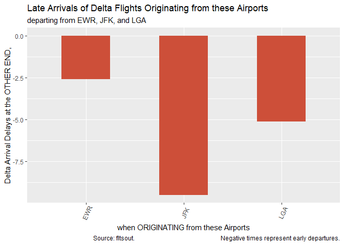

```r
ggplot(fodlgrpd, aes(x = origin, y = meandlarrdelay)) +
  geom_bar(stat="identity", width=.5, fill="tomato3") +
  labs(title="Late Arrivals of Delta Flights Originating from these Airports",
       subtitle="departing from EWR, JFK, and LGA",
       caption="Source: fltsout.                                                        Negative times represent early departures.",
       y = "Delta Arrival Delays at the OTHER END,",
       x = "when ORIGINATING from these Airports") +
  theme(axis.text.x = element_text(angle=65, vjust=0.6))
```

### Interpretation:

Note that negative numbrs are early arrivals, so the latest arrivals have the largest positive number.  
Note that we are measuring the arrival at ANOTHER airport, of flights ORIGINATING at these three airports.  
JFK has the largest negative number, meaning that it has the earliest arrival times.

## Question 3. Which destination airport is the worst (based on Mean Arrival Delays) airport for arrival time?

```r
library(ggplot2)
library(dplyr)
library(tidyverse)

flts <- nycflights13::flights
str(flts)
```

```
## tibble [336,776 x 19] (S3: tbl_df/tbl/data.frame)
##  $ year          : int [1:336776] 2013 2013 2013 2013 2013 2013 2013 2013 2013 2013 ...
##  $ month         : int [1:336776] 1 1 1 1 1 1 1 1 1 1 ...
##  $ day           : int [1:336776] 1 1 1 1 1 1 1 1 1 1 ...
##  $ dep_time      : int [1:336776] 517 533 542 544 554 554 555 557 557 558 ...
##  $ sched_dep_time: int [1:336776] 515 529 540 545 600 558 600 600 600 600 ...
##  $ dep_delay     : num [1:336776] 2 4 2 -1 -6 -4 -5 -3 -3 -2 ...
##  $ arr_time      : int [1:336776] 830 850 923 1004 812 740 913 709 838 753 ...
##  $ sched_arr_time: int [1:336776] 819 830 850 1022 837 728 854 723 846 745 ...
##  $ arr_delay     : num [1:336776] 11 20 33 -18 -25 12 19 -14 -8 8 ...
##  $ carrier       : chr [1:336776] "UA" "UA" "AA" "B6" ...
##  $ flight        : int [1:336776] 1545 1714 1141 725 461 1696 507 5708 79 301 ...
##  $ tailnum       : chr [1:336776] "N14228" "N24211" "N619AA" "N804JB" ...
##  $ origin        : chr [1:336776] "EWR" "LGA" "JFK" "JFK" ...
##  $ dest          : chr [1:336776] "IAH" "IAH" "MIA" "BQN" ...
##  $ air_time      : num [1:336776] 227 227 160 183 116 150 158 53 140 138 ...
##  $ distance      : num [1:336776] 1400 1416 1089 1576 762 ...
##  $ hour          : num [1:336776] 5 5 5 5 6 5 6 6 6 6 ...
##  $ minute        : num [1:336776] 15 29 40 45 0 58 0 0 0 0 ...
##  $ time_hour     : POSIXct[1:336776], format: "2013-01-01 05:00:00" "2013-01-01 05:00:00" ...
```

```r
unique(flts$origin)   #EWR, JFK, LGA
```

```
## [1] "EWR" "LGA" "JFK"
```

```r
unique(flts$dest)    # 105 different destinations
```

```
##   [1] "IAH" "MIA" "BQN" "ATL" "ORD" "FLL" "IAD" "MCO" "PBI" "TPA" "LAX" "SFO"
##  [13] "DFW" "BOS" "LAS" "MSP" "DTW" "RSW" "SJU" "PHX" "BWI" "CLT" "BUF" "DEN"
##  [25] "SNA" "MSY" "SLC" "XNA" "MKE" "SEA" "ROC" "SYR" "SRQ" "RDU" "CMH" "JAX"
##  [37] "CHS" "MEM" "PIT" "SAN" "DCA" "CLE" "STL" "MYR" "JAC" "MDW" "HNL" "BNA"
##  [49] "AUS" "BTV" "PHL" "STT" "EGE" "AVL" "PWM" "IND" "SAV" "CAK" "HOU" "LGB"
##  [61] "DAY" "ALB" "BDL" "MHT" "MSN" "GSO" "CVG" "BUR" "RIC" "GSP" "GRR" "MCI"
##  [73] "ORF" "SAT" "SDF" "PDX" "SJC" "OMA" "CRW" "OAK" "SMF" "TUL" "TYS" "OKC"
##  [85] "PVD" "DSM" "PSE" "BHM" "CAE" "HDN" "BZN" "MTJ" "EYW" "PSP" "ACK" "BGR"
##  [97] "ABQ" "ILM" "MVY" "SBN" "LEX" "CHO" "TVC" "ANC" "LGA"
```

```r
outliers <- boxplot(flts$arr_delay, plot=FALSE)$out #assign the outlier values into a vector
print(outliers) # Check the results
```

```
##     [1]  137  851  123  145   78   81   93   78   73  103   84   66   65   83
##    [15]  127  125  115   91  136   65  123   67   78   72   80   67   96   68
##    [29]   61  107  123   68   66   65  138  116  338   94  263   78  127   81
##    [43]  151  166  174   75  222   83  123   91   61  250  142  246   73  127
##    [57]  191   69   73  456  154   90   75  142  171   70   65  173   84   62
##    [71]   99   97   72   85   63   73   98  102  207   83  288   96  107  323
##    [85]   85  136   65  119  130  109   63   69   81  368   67  102   96   70
##    [99]  122   82   82  131   69   71  166   80  141   69  107   99  120   85
##   [113]  106   81   77  158  136  180  102  116   64   68   84  176   88  182
##   [127]   82   83  157  359  130   82   89  252  110  100  111  101   61  172
##   [141]  143   92  111  167  133  138   83   96  -65  102   72   85   97   61
##   [155]   67  113   79   81  128   70  175   63   63   71  110   81  141  176
##   [169]   66   64  127   72   98   67   62   71   85  270  257   80  105   65
##   [183]  111   71  285   67   75  150   89   90  141  125  -70   62  126  161
##   [197]   61   65  162   79   65   81   66   97  105   62  109  118   98   93
```

[output cut: 1977 more lines]

```r
flts[which(flts$arr_delay %in% outliers),] # First you need find in which rows the outliers are
```

```
## # A tibble: 27,880 x 19
##     year month   day dep_time sched_dep_time dep_delay arr_time sched_arr_time
##    <int> <int> <int>    <int>          <int>     <dbl>    <int>          <int>
##  1  2013     1     1      811            630       101     1047            830
##  2  2013     1     1      848           1835       853     1001           1950
##  3  2013     1     1      957            733       144     1056            853
##  4  2013     1     1     1114            900       134     1447           1222
##  5  2013     1     1     1120            944        96     1331           1213
##  6  2013     1     1     1255           1200        55     1451           1330
##  7  2013     1     1     1301           1150        71     1518           1345
##  8  2013     1     1     1337           1220        77     1649           1531
##  9  2013     1     1     1342           1320        22     1617           1504
## 10  2013     1     1     1400           1250        70     1645           1502
## # ... with 27,870 more rows, and 11 more variables: arr_delay <dbl>,
## #   carrier <chr>, flight <int>, tailnum <chr>, origin <chr>, dest <chr>,
## #   air_time <dbl>, distance <dbl>, hour <dbl>, minute <dbl>, time_hour <dttm>
```

```r
fltsout <- flts[-which(flts$arr_delay %in% outliers),]  #remove the rows containing the outliers
str(fltsout)  #look at the data without outliers
```

```
## tibble [308,896 x 19] (S3: tbl_df/tbl/data.frame)
##  $ year          : int [1:308896] 2013 2013 2013 2013 2013 2013 2013 2013 2013 2013 ...
##  $ month         : int [1:308896] 1 1 1 1 1 1 1 1 1 1 ...
##  $ day           : int [1:308896] 1 1 1 1 1 1 1 1 1 1 ...
##  $ dep_time      : int [1:308896] 517 533 542 544 554 554 555 557 557 558 ...
##  $ sched_dep_time: int [1:308896] 515 529 540 545 600 558 600 600 600 600 ...
##  $ dep_delay     : num [1:308896] 2 4 2 -1 -6 -4 -5 -3 -3 -2 ...
##  $ arr_time      : int [1:308896] 830 850 923 1004 812 740 913 709 838 753 ...
##  $ sched_arr_time: int [1:308896] 819 830 850 1022 837 728 854 723 846 745 ...
##  $ arr_delay     : num [1:308896] 11 20 33 -18 -25 12 19 -14 -8 8 ...
##  $ carrier       : chr [1:308896] "UA" "UA" "AA" "B6" ...
##  $ flight        : int [1:308896] 1545 1714 1141 725 461 1696 507 5708 79 301 ...
##  $ tailnum       : chr [1:308896] "N14228" "N24211" "N619AA" "N804JB" ...
##  $ origin        : chr [1:308896] "EWR" "LGA" "JFK" "JFK" ...
##  $ dest          : chr [1:308896] "IAH" "IAH" "MIA" "BQN" ...
##  $ air_time      : num [1:308896] 227 227 160 183 116 150 158 53 140 138 ...
##  $ distance      : num [1:308896] 1400 1416 1089 1576 762 ...
##  $ hour          : num [1:308896] 5 5 5 5 6 5 6 6 6 6 ...
##  $ minute        : num [1:308896] 15 29 40 45 0 58 0 0 0 0 ...
##  $ time_hour     : POSIXct[1:308896], format: "2013-01-01 05:00:00" "2013-01-01 05:00:00" ...
```

```r
summary(fltsout)  #look at the data without outliers
```

```
##       year          month             day           dep_time    sched_dep_time
##  Min.   :2013   Min.   : 1.000   Min.   : 1.00   Min.   :   1   Min.   : 106
##  1st Qu.:2013   1st Qu.: 4.000   1st Qu.: 8.00   1st Qu.: 856   1st Qu.: 900
##  Median :2013   Median : 7.000   Median :16.00   Median :1332   Median :1330
##  Mean   :2013   Mean   : 6.565   Mean   :15.71   Mean   :1317   Mean   :1322
##  3rd Qu.:2013   3rd Qu.:10.000   3rd Qu.:23.00   3rd Qu.:1719   3rd Qu.:1715
##  Max.   :2013   Max.   :12.000   Max.   :31.00   Max.   :2400   Max.   :2359
##                                                  NA's   :8255
##    dep_delay          arr_time    sched_arr_time   arr_delay
##  Min.   :-43.000   Min.   :   1   Min.   :   1   Min.   :-63.000
##  1st Qu.: -5.000   1st Qu.:1102   1st Qu.:1115   1st Qu.:-18.000
##  Median : -2.000   Median :1518   Median :1533   Median : -7.000
##  Mean   :  3.408   Mean   :1498   Mean   :1518   Mean   : -3.686
##  3rd Qu.:  5.000   3rd Qu.:1924   3rd Qu.:1930   3rd Qu.:  7.000
##  Max.   :634.000   Max.   :2400   Max.   :2359   Max.   : 60.000
##  NA's   :8255      NA's   :8713                  NA's   :9430
##    carrier              flight       tailnum             origin
##  Length:308896      Min.   :   1   Length:308896      Length:308896
##  Class :character   1st Qu.: 549   Class :character   Class :character
##  Mode  :character   Median :1481   Mode  :character   Mode  :character
##                     Mean   :1945
##                     3rd Qu.:3407
##                     Max.   :6181
##
##      dest              air_time        distance         hour
##  Length:308896      Min.   : 20.0   Min.   :  17   Min.   : 1.00
##  Class :character   1st Qu.: 83.0   1st Qu.: 502   1st Qu.: 9.00
##  Mode  :character   Median :130.0   Median : 888   Median :13.00
##                     Mean   :151.5   Mean   :1047   Mean   :12.96
##                     3rd Qu.:193.0   3rd Qu.:1389   3rd Qu.:17.00
##                     Max.   :691.0   Max.   :4983   Max.   :23.00
##                     NA's   :9430
##      minute        time_hour
##  Min.   : 0.00   Min.   :2013-01-01 05:00:00
##  1st Qu.: 8.00   1st Qu.:2013-04-03 14:00:00
##  Median :29.00   Median :2013-07-05 07:00:00
##  Mean   :26.12   Mean   :2013-07-03 17:37:40
##  3rd Qu.:44.00   3rd Qu.:2013-10-02 18:00:00
##  Max.   :59.00   Max.   :2013-12-31 23:00:00
##
```

```r
fobydest <- group_by(fltsout, dest)
fobydest
```

```
## # A tibble: 308,896 x 19
## # Groups:   dest [105]
##     year month   day dep_time sched_dep_time dep_delay arr_time sched_arr_time
##    <int> <int> <int>    <int>          <int>     <dbl>    <int>          <int>
##  1  2013     1     1      517            515         2      830            819
##  2  2013     1     1      533            529         4      850            830
##  3  2013     1     1      542            540         2      923            850
##  4  2013     1     1      544            545        -1     1004           1022
##  5  2013     1     1      554            600        -6      812            837
##  6  2013     1     1      554            558        -4      740            728
##  7  2013     1     1      555            600        -5      913            854
##  8  2013     1     1      557            600        -3      709            723
##  9  2013     1     1      557            600        -3      838            846
## 10  2013     1     1      558            600        -2      753            745
## # ... with 308,886 more rows, and 11 more variables: arr_delay <dbl>,
## #   carrier <chr>, flight <int>, tailnum <chr>, origin <chr>, dest <chr>,
## #   air_time <dbl>, distance <dbl>, hour <dbl>, minute <dbl>, time_hour <dttm>
```

```r
fobdgrpd <- summarise(fobydest, meanarrdelay = mean(arr_delay, na.rm = TRUE)) # Produce the mean for each airport
fobdgrpd
```

```
## # A tibble: 105 x 2
##    dest  meanarrdelay
##    <chr>        <dbl>
##  1 ABQ         -6.24
##  2 ACK         -0.171
##  3 ALB         -2.08
##  4 ANC         -2.5
##  5 ATL          0.264
##  6 AUS         -4.98
##  7 AVL          0.362
##  8 BDL         -4.31
##  9 BGR         -6.16
## 10 BHM         -4.63
## # ... with 95 more rows
```

```r
fobdgrpdbad <- filter(fobdgrpd, meanarrdelay >= 0)    #extract only those with positive meanarrdelay; i.e., bad
fobdgrpdbad
```

```
## # A tibble: 19 x 2
##    dest  meanarrdelay
##    <chr>        <dbl>
##  1 ATL          0.264
##  2 AVL          0.362
##  3 BQN          0.913
##  4 BZN          1
##  5 CAE         16.2
##  6 CAK          2.42
##  7 EYW          6.35
##  8 GRR          2.70
##  9 GSP          0.956
## 10 HDN          2.14
## 11 JAC         15.1
## 12 MSN          1.65
## 13 OKC          7.53
## 14 PSE          0.617
## 15 PVD          1.47
## 16 RIC          0.555
## 17 SBN          6.5
## 18 SMF          0.6
## 19 TUL          5.03
```

[output not shown]

[output cut: 172 more lines]

[output not shown]

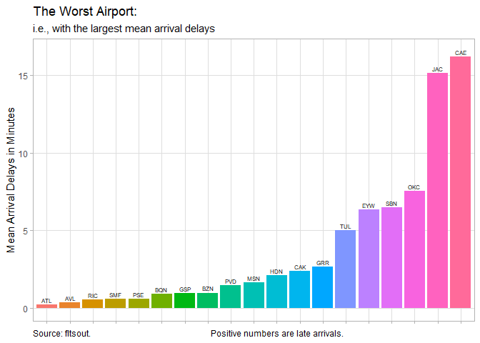

```r
fobdgrpdbad$destf <- as.factor(fobdgrpdbad$dest)
fobdgrpdbad$meanarrdelayf <- as.factor(fobdgrpdbad$meanarrdelay)

# Draw Ordered Bar Chart plot
ggplot(fobdgrpdbad, aes(x = reorder(meanarrdelay,dest), y = meanarrdelay)) +
  geom_bar(stat="identity", width=.5, fill="tomato3") +
  geom_col(aes(fill = meanarrdelayf)) +
  #  geom_text(aes(label = meandlarrdelay), nudge_x = 0.15, nudge_y = -1,size = rel(2)) +
  geom_text(aes(label = dest), nudge_x = 0, nudge_y = 0.3,size = rel(2)) +
  labs(title="The Worst Airport:",
       subtitle="i.e., with the largest mean arrival delays",
       caption="Source: fltsout.                                                        Positive numbers are late arrivals.",
       y = "Mean Arrival Delays in Minutes",
       x = "Airports") +
#  theme(axis.text.x = element_text(angle=90, vjust=0.5))
  theme_light() +
  theme(plot.caption = element_text(hjust = 0),   #left-justify the caption (default is right-justified) https://ggplot2.tidyverse.org/reference/theme.html
        axis.title.x = element_blank(),            #deletes the axis titles
        #axis.title.y = element_blank(),
        legend.position = "none",                  #deletes the legend
        #panel.grid.major.y = element_blank(),       #deletes the horizontal gridlines
        panel.grid.minor.y = element_blank(),
        axis.text.x = element_blank(),             #deletes the x axis ticks and numbers    axis.ticks.y = element_blank())
  )
```

### Interpretation:

Note that negative numbers are early arrivals, so the worst airports have the largest positive mean.  
CAE (Columbia, South Carolina) and JAC (Jackson Hole, Wyoming) are by far the worst airports.

[ ] Address at least two of the three questions stated in the background description (if you have time try to tackle all three).  
[ ] Make sure to include one or more visualization that shows the complexity of the data.  
[ ] Create one .rmd file that has your report.  
[ ] Have a section for each question.  
[ ] Make sure your code is in the report but defaults to hidden. (In the YAML include code_folding: hide)  
[ ] Write an introduction section that describes your results.  
[ ] Make a plot of the data to show the answer to the specific question.  
[ ] Push your .Rmd, .md, and .html to your GitHub repo Week_04 file.  
[ ] Be prepared to discuss your analysis in the upcoming class.  
[ ] Complete the recommended reading on posting issues.  
[ ] Find two other student’s compiled files in their repository and provide feedback using the issues feature in GitHub (If they already have two issues find a different student to critique)  
[ ] Address 1-2 of the issues posted on your project and push the updates to GitHub